# vis_4

2022-11-13

0. 환경 설정

# 6. 모형을 사용한 작업

- 데이터 시각화는 데이터 테이블에서 원(raw) 수량을 표시하는 모양을 생성하는 것 이상의 의미를 지닌다. 처음부터 데이터의 일부를 요약하거나 변형한 다음, 결과를 도표화하는 작업이 포함된다.
- 통계 모형은 이 프로세스의 핵심이다. 6장에서는 ggplot이 geom에서 다양한 모델링 기법을 직접 사용하는 방법을 간략하게 살펴볼 것이다. 그런 다음 broom과 margin 라이브러리를 사용해 자신에게 맞는 모형으로부터 추정치를 추출하고 계획하는 방법을 설명한다.

```r
p <- ggplot(data = gapminder,
            mapping = aes(x = log(gdpPercap), y = lifeExp))
```

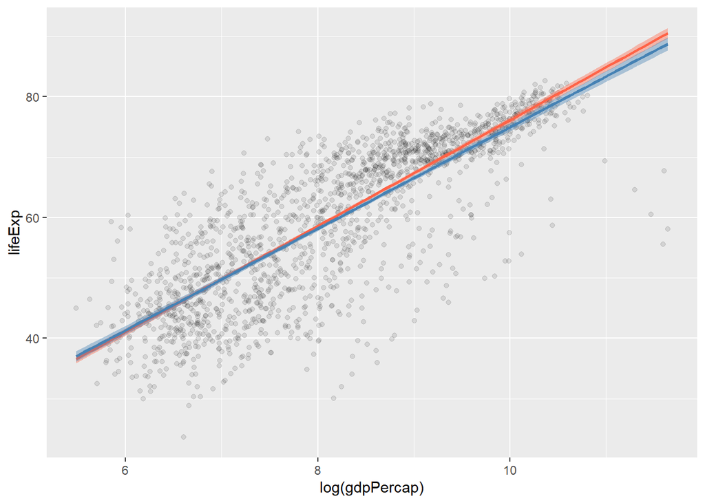

```r
p + geom_point(alpha = 0.1) +
    geom_smooth(color = "tomato", fill = "tomato", method = MASS::rlm) +
    geom_smooth(color = "steelblue", fill = "steelblue", method = "lm")
```

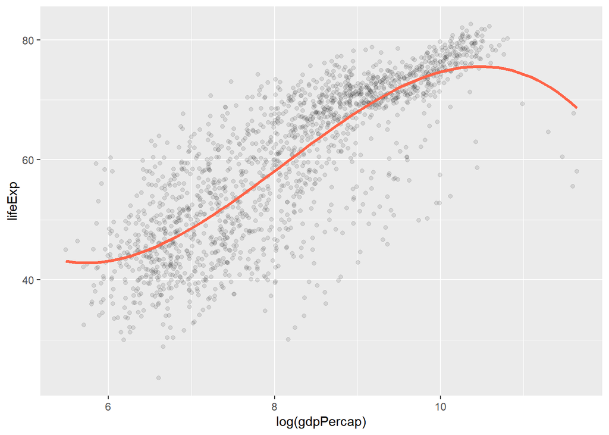

```r
p + geom_point(alpha = 0.1) +
    geom_smooth(color = "tomato", method = "lm", size = 1.2, formula = y ~ splines::bs(x, 3), se = FALSE)
```

```
## Smoothing formula not specified. Using: y ~ qss(x, lambda = 1)
```

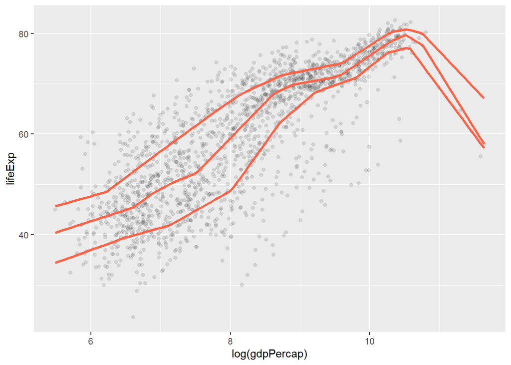

```r
p + geom_point(alpha = 0.1) +
    geom_quantile(color = "tomato", size = 1.2, method = "rqss",
                  lambda = 1, quantiles = c(0.20, 0.5, 0.8))
```

- 히스토그램, 밀도 도표, 박스플롯 및 기타 geom은 도표화하기 전에 하나의 숫자 또는 새로운 변수를 계산한다.
- 4.4절에서 봤듯이 이런 계산은 stat_ 함수에의해 수행되며, 각 함수는 기본 geom_ 함수와 함께 작동하고 그 반대의 경우도 마찬가지이다.
- geom_smooth() 함수는 LOESS, OLS, 로버스트 회귀선(robust regressioin line)과 같이 다양한 메서드 인자를 사용할 수 있다.
- geom_quantile() 함수는 geom_smooth()의 특수 버전과 비슷하며, 다양한 메서드를 사용해 분위수 회귀선을 적합시킬 수 있다. (함수 내 quantiles 인자는 회귀선 적합을 위한(신뢰구간) 숫자를 지정하는 벡터를 취함)

## 6.1 범례와 함께 한 번에 여러 적합 보여주기

- geom_smooth()를 사용해 새로운 추세선 레이어를 겹쳐서 동일한도표에서 한 번에 여러 가지 모양을 볼 수 있음
- 색상(color)과 채우기(fill) aes를 각 적합마다 다른 값으로 설정하면 시각적으로 쉽게 구별할 수 있음
- 여러 다른 적합도를 비교하고 그것들을 설명하는 범례가 필요하다면 어떻게 해야 할까?
  - geom_smooth()는 색상과 채우기 aes를 피팅하고 있는 모형을 설명하는 문자열에 매핑한 다음 scale_color_manual()과 scale_fill_manual()을 사용해 범례를 만드는 약간 특이한 경로를 통해 이 작업을 수행함

```r
model_colors <- RColorBrewer::brewer.pal(3, "Set1")
model_colors
```

```
## [1] "#E41A1C" "#377EB8" "#4DAF4A"
```

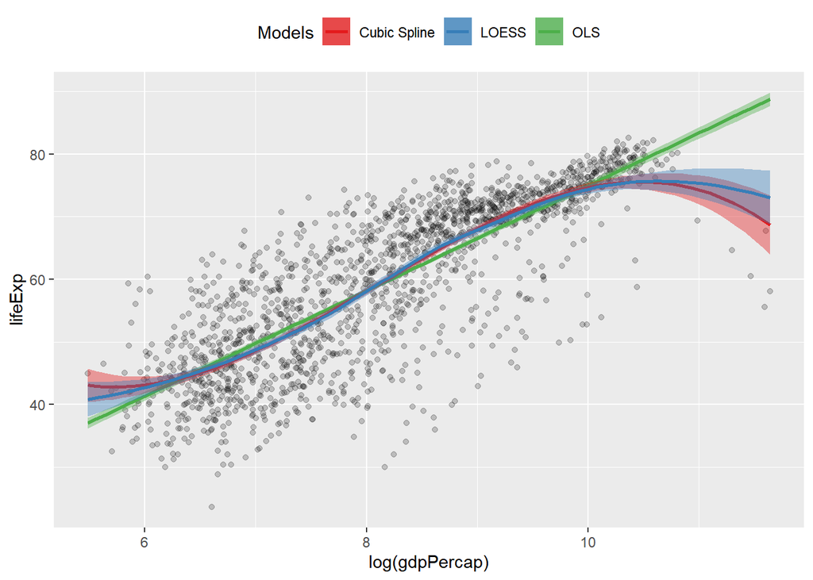

```r
p0 <- ggplot(data = gapminder,
             mapping = aes(x = log(gdpPercap), y = lifeExp))

p1 <- p0 + geom_point(alpha = 0.2) +
           geom_smooth(method = "lm",
                       aes(color = "OLS", fill = "OLS")) +
           geom_smooth(method = "lm", formula = y ~ splines::bs(x, df = 3),
                       aes(color = "Cubic Spline", fill = "Cubic Spline")) +
           geom_smooth(method = "loess",
                       aes(color = "LOESS", fill = "LOESS"))

p1 + scale_color_manual(name = "Models", values = model_colors) +
     scale_fill_manual(name = "Models", values = model_colors) +
     theme(legend.position = "top")
```

## 6.2 모델 객체 내부 보기

```r
gapminder
```

```
## # A tibble: 1,704 × 6
##    country     continent  year lifeExp      pop gdpPercap
##    <fct>       <fct>     <int>   <dbl>    <int>     <dbl>
##  1 Afghanistan Asia       1952    28.8  8425333      779.
##  2 Afghanistan Asia       1957    30.3  9240934      821.
##  3 Afghanistan Asia       1962    32.0 10267083      853.
##  4 Afghanistan Asia       1967    34.0 11537966      836.
##  5 Afghanistan Asia       1972    36.1 13079460      740.
##  6 Afghanistan Asia       1977    38.4 14880372      786.
##  7 Afghanistan Asia       1982    39.9 12881816      978.
##  8 Afghanistan Asia       1987    40.8 13867957      852.
##  9 Afghanistan Asia       1992    41.7 16317921      649.
## 10 Afghanistan Asia       1997    41.8 22227415      635.
## # … with 1,694 more rows
```

- 객체의 구조는 gapminder로 확인 가능

```r
str(gapminder)
```

```
## tibble [1,704 × 6] (S3: tbl_df/tbl/data.frame)
##  $ country  : Factor w/ 142 levels "Afghanistan",..: 1 1 1 1 1 1 1 1 1 1 ...
##  $ continent: Factor w/ 5 levels "Africa","Americas",..: 3 3 3 3 3 3 3 3 3 3 ...
##  $ year     : int [1:1704] 1952 1957 1962 1967 1972 1977 1982 1987 1992 1997 ...
##  $ lifeExp  : num [1:1704] 28.8 30.3 32 34 36.1 ...
##  $ pop      : int [1:1704] 8425333 9240934 10267083 11537966 13079460 14880372 12881816 13867957 16317921 22227415 ...
##  $ gdpPercap: num [1:1704] 779 821 853 836 740 ...
```

- gapminder 데이터를 사용해 선형 모형, 표준 OLS 회귀를 만듦

```r
out <- lm(formula = lifeExp ~ gdpPercap + pop + continent, data = gapminder)

summary(out)
```

```
##
## Call:
## lm(formula = lifeExp ~ gdpPercap + pop + continent, data = gapminder)
##
## Residuals:
##     Min      1Q  Median      3Q     Max
## -49.161  -4.486   0.297   5.110  25.175
##
## Coefficients:
##                    Estimate Std. Error t value Pr(>|t|)
## (Intercept)       4.781e+01  3.395e-01 140.819  < 2e-16 ***
## gdpPercap         4.495e-04  2.346e-05  19.158  < 2e-16 ***
## pop               6.570e-09  1.975e-09   3.326 0.000901 ***
## continentAmericas 1.348e+01  6.000e-01  22.458  < 2e-16 ***
## continentAsia     8.193e+00  5.712e-01  14.342  < 2e-16 ***
## continentEurope   1.747e+01  6.246e-01  27.973  < 2e-16 ***
## continentOceania  1.808e+01  1.782e+00  10.146  < 2e-16 ***
## ---
## Signif. codes:  0 '***' 0.001 '**' 0.01 '*' 0.05 '.' 0.1 ' ' 1
##
## Residual standard error: 8.365 on 1697 degrees of freedom
## Multiple R-squared:  0.5821, Adjusted R-squared:  0.5806
## F-statistic: 393.9 on 6 and 1697 DF,  p-value: < 2.2e-16
```

```r
str(out)
```

```
## List of 13
##  $ coefficients : Named num [1:7] 4.78e+01 4.50e-04 6.57e-09 1.35e+01 8.19 ...
##   ..- attr(*, "names")= chr [1:7] "(Intercept)" "gdpPercap" "pop" "continentAmericas" ...
##  $ residuals    : Named num [1:1704] -27.6 -26.1 -24.5 -22.4 -20.3 ...
##   ..- attr(*, "names")= chr [1:1704] "1" "2" "3" "4" ...
##  $ effects      : Named num [1:1704] -2455.1 311.1 42.6 101.1 -17.2 ...
##   ..- attr(*, "names")= chr [1:1704] "(Intercept)" "gdpPercap" "pop" "continentAmericas" ...
##  $ rank         : int 7
##  $ fitted.values: Named num [1:1704] 56.4 56.4 56.5 56.5 56.4 ...
##   ..- attr(*, "names")= chr [1:1704] "1" "2" "3" "4" ...
##  $ assign       : int [1:7] 0 1 2 3 3 3 3
##  $ qr           :List of 5
##   ..$ qr   : num [1:1704, 1:7] -41.2795 0.0242 0.0242 0.0242 0.0242 ...
##   .. ..- attr(*, "dimnames")=List of 2
##   .. .. ..$ : chr [1:1704] "1" "2" "3" "4" ...
##   .. .. ..$ : chr [1:7] "(Intercept)" "gdpPercap" "pop" "continentAmericas" ...
##   .. ..- attr(*, "assign")= int [1:7] 0 1 2 3 3 3 3
##   .. ..- attr(*, "contrasts")=List of 1
##   .. .. ..$ continent: chr "contr.treatment"
##   ..$ qraux: num [1:7] 1.02 1.02 1 1.01 1.04 ...
##   ..$ pivot: int [1:7] 1 2 3 4 5 6 7
##   ..$ tol  : num 1e-07
##   ..$ rank : int 7
##   ..- attr(*, "class")= chr "qr"
##  $ df.residual  : int 1697
##  $ contrasts    :List of 1
##   ..$ continent: chr "contr.treatment"
##  $ xlevels      :List of 1
##   ..$ continent: chr [1:5] "Africa" "Americas" "Asia" "Europe" ...
##  $ call         : language lm(formula = lifeExp ~ gdpPercap + pop + continent, data = gapminder)
##  $ terms        :Classes 'terms', 'formula'  language lifeExp ~ gdpPercap + pop + continent
##   .. ..- attr(*, "variables")= language list(lifeExp, gdpPercap, pop, continent)
##   .. ..- attr(*, "factors")= int [1:4, 1:3] 0 1 0 0 0 0 1 0 0 0 ...
##   .. .. ..- attr(*, "dimnames")=List of 2
##   .. .. .. ..$ : chr [1:4] "lifeExp" "gdpPercap" "pop" "continent"
##   .. .. .. ..$ : chr [1:3] "gdpPercap" "pop" "continent"
##   .. ..- attr(*, "term.labels")= chr [1:3] "gdpPercap" "pop" "continent"
##   .. ..- attr(*, "order")= int [1:3] 1 1 1
##   .. ..- attr(*, "intercept")= int 1
##   .. ..- attr(*, "response")= int 1
```

[output cut: 9 more lines]

```
##   ..- attr(*, "terms")=Classes 'terms', 'formula'  language lifeExp ~ gdpPercap + pop + continent
##   .. .. ..- attr(*, "variables")= language list(lifeExp, gdpPercap, pop, continent)
##   .. .. ..- attr(*, "factors")= int [1:4, 1:3] 0 1 0 0 0 0 1 0 0 0 ...
##   .. .. .. ..- attr(*, "dimnames")=List of 2
##   .. .. .. .. ..$ : chr [1:4] "lifeExp" "gdpPercap" "pop" "continent"
##   .. .. .. .. ..$ : chr [1:3] "gdpPercap" "pop" "continent"
##   .. .. ..- attr(*, "term.labels")= chr [1:3] "gdpPercap" "pop" "continent"
##   .. .. ..- attr(*, "order")= int [1:3] 1 1 1
##   .. .. ..- attr(*, "intercept")= int 1
##   .. .. ..- attr(*, "response")= int 1
##   .. .. ..- attr(*, ".Environment")=<environment: R_GlobalEnv>
##   .. .. ..- attr(*, "predvars")= language list(lifeExp, gdpPercap, pop, continent)
##   .. .. ..- attr(*, "dataClasses")= Named chr [1:4] "numeric" "numeric" "numeric" "factor"
##   .. .. .. ..- attr(*, "names")= chr [1:4] "lifeExp" "gdpPercap" "pop" "continent"
##  - attr(*, "class")= chr "lm"
```

## 6.3 모형 기반 그래픽을 올바르게 얻기

- 실질적인 용어로 연구 결과 제시
- 신뢰성의 정도를 보여라
- 가능한 경우 데이터를 보여준다

## 6.4 그래프로 예측 생성

- predict에 사용할 확장 데이터 생성

```r
min_gdp <- min(gapminder$gdpPercap)
max_gdp <- max(gapminder$gdpPercap)
med_pop <- median(gapminder$pop)

pred_df <- expand.grid(gdpPercap = (seq(from = min_gdp, to = max_gdp, length.out = 100)),
                       pop = med_pop,
                       continent = c("Africa", "Americas", "Asia", "Europe", "Oceania"))

dim(pred_df)
```

```
## [1] 500   3
```

```r
head(pred_df)
```

```
##   gdpPercap     pop continent
## 1  241.1659 7023596    Africa
## 2 1385.4282 7023596    Africa
## 3 2529.6905 7023596    Africa
## 4 3673.9528 7023596    Africa
## 5 4818.2150 7023596    Africa
## 6 5962.4773 7023596    Africa
```

- 함수에 새로운 데이터와 모형을 제공하면 추가 인자 없이 데이터 프레임의 모든 행에 맞는 값이 계산됨
- interval = “predict”를 인자로 지정하면 점 추정에 추가해 95% 예측 구간을 계산함

```r
pred_out <- predict(object = out,
                    newdata = pred_df,
                    interval = "predict")
head(pred_out)
```

```
##        fit      lwr      upr
## 1 47.96863 31.54775 64.38951
## 2 48.48298 32.06231 64.90365
## 3 48.99733 32.57670 65.41797
## 4 49.51169 33.09092 65.93245
## 5 50.02604 33.60497 66.44711
## 6 50.54039 34.11885 66.96193
```

- 구성상 pred_df 및 pred_out의 경우는 행에 대응하므로 두 데이터 프레임을 열로 함께 묶을 수 있다. (cbind)

```r
pred_df <- cbind(pred_df, pred_out)
head(pred_df)
```

```
##   gdpPercap     pop continent      fit      lwr      upr
## 1  241.1659 7023596    Africa 47.96863 31.54775 64.38951
## 2 1385.4282 7023596    Africa 48.48298 32.06231 64.90365
## 3 2529.6905 7023596    Africa 48.99733 32.57670 65.41797
## 4 3673.9528 7023596    Africa 49.51169 33.09092 65.93245
## 5 4818.2150 7023596    Africa 50.02604 33.60497 66.44711
## 6 5962.4773 7023596    Africa 50.54039 34.11885 66.96193
```

- 유럽과 아프리카에 대한 예상치를 서브셋으로 사용하여 플랏 실시

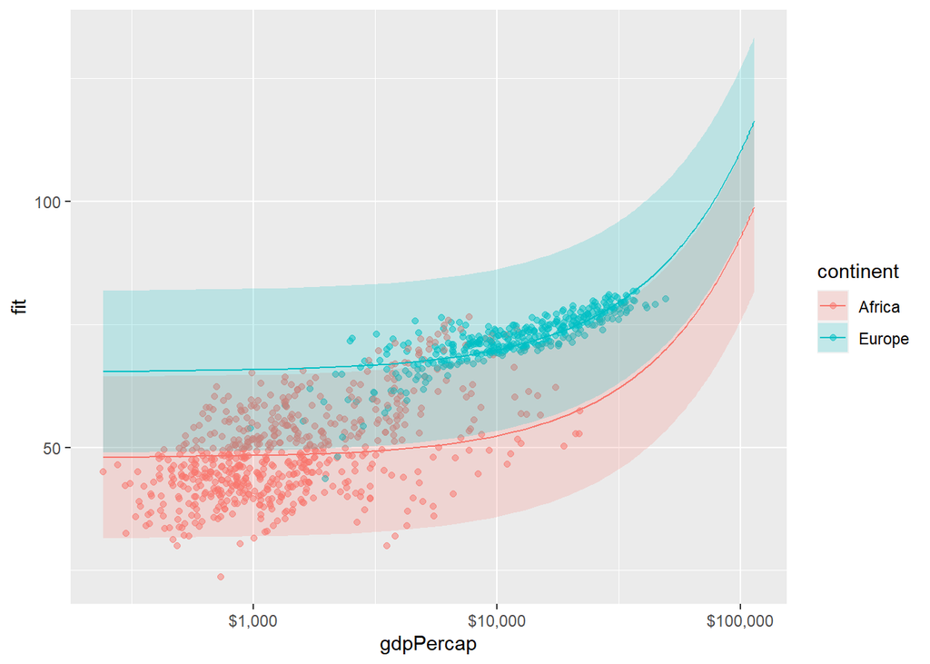

```r
p <- ggplot(data = subset(pred_df, continent %in% c("Europe", "Africa")),
            aes(x = gdpPercap, y = fit,
                ymin = lwr, ymax = upr,
                color = continent,
                fill = continent,
                group = continent))

p + geom_point(data = subset(gapminder, continent %in% c("Europe", "Africa")),
               mapping = aes(x = gdpPercap, y = lifeExp, color = continent),
               alpha = 0.5,
               inherit.aes = FALSE) +
    geom_line() +
    geom_ribbon(alpha = 0.2, color = FALSE) +
    scale_x_log10(labels = scales::dollar)
```

## 6.5 broom의 깔끔한 모델 객체

- predict 메서드는 매우 유용하지만 모형 출력과 함께할 수 있는 많은 다른 것들이 있다.
- 데이비드 로빈슨의 broom 패키지를 사용해 볼 것이다.

```r
library(broom)
search()
```

```
##  [1] ".GlobalEnv"        "package:broom"     "package:socviz"
##  [4] "package:forcats"   "package:stringr"   "package:dplyr"
##  [7] "package:purrr"     "package:readr"     "package:tidyr"
## [10] "package:tibble"    "package:ggplot2"   "package:tidyverse"
## [13] "package:gapminder" "package:stats"     "package:graphics"
## [16] "package:grDevices" "package:utils"     "package:datasets"
## [19] "package:methods"   "Autoloads"         "package:base"
```

- `broom`은 ggplot의 접근 방식을 이용해 R이 깔끔한 데이터를 생성하는 모델 객체로 확장한다.
  1. 계수 및 t-통계량과 같은 모형 자체의 측면에 대한 구성 요소 수준(component-level) 정보를 볼 수 있다.
  2. 기본 데이터에 대한 모형의 연결에 대한 관측 수준(observation-level) 정보를 얻을 수 있다.
  3. F-통계, 모형 편차 또는 r-제곱과 같이 전체적으로 피팅을 요약하는 모형 수준(model-level)의 정보를 얻을 수 있다.

### 6.5.1 tidy()로 구성요소 수준 통계 가져오기

tidy() 함수는 모델 객체를 가져오고 구성요소 수준 정보의 데이터프레임을 반환한다.

```r
out_comp <- tidy(out)
out_comp %>% round_df()
```

```
## # A tibble: 7 × 5
##   term              estimate std.error statistic p.value
##   <chr>                <dbl>     <dbl>     <dbl>   <dbl>
## 1 (Intercept)          47.8       0.34    141.         0
## 2 gdpPercap             0         0        19.2        0
## 3 pop                   0         0         3.33       0
## 4 continentAmericas    13.5       0.6      22.5        0
## 5 continentAsia         8.19      0.57     14.3        0
## 6 continentEurope      17.5       0.62     28.0        0
## 7 continentOceania     18.1       1.78     10.2        0
```

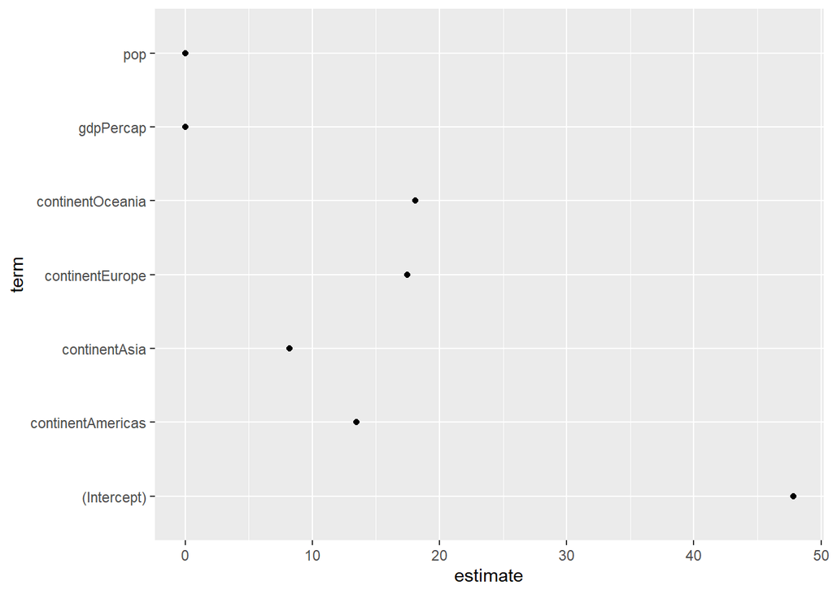

```r
p <- ggplot(out_comp, mapping = aes(x = term, y = estimate))

p + geom_point() + coord_flip()
```

다양한 방법으로 이 도표를 확장하고 정리할 수 있다. 이를테면 tidy()가 R의 confint() 함수를 사용해 추정치의 신뢰구간을 계산하도록 명령할 수 있다.

```r
out_conf <- tidy(out, conf.int = TRUE)
out_conf %>% round_df()
```

```
## # A tibble: 7 × 7
##   term              estimate std.error statistic p.value conf.low conf.high
##   <chr>                <dbl>     <dbl>     <dbl>   <dbl>    <dbl>     <dbl>
## 1 (Intercept)          47.8       0.34    141.         0    47.2      48.5
## 2 gdpPercap             0         0        19.2        0     0         0
## 3 pop                   0         0         3.33       0     0         0
## 4 continentAmericas    13.5       0.6      22.5        0    12.3      14.6
## 5 continentAsia         8.19      0.57     14.3        0     7.07      9.31
## 6 continentEurope      17.5       0.62     28.0        0    16.2      18.7
## 7 continentOceania     18.1       1.78     10.2        0    14.6      21.6
```

편리한 “not in” 연산자 %nin%는 socviz 라이브러리를 통해 사용할 수 있다. 이를 활용해표에서 절편항을 삭제한다.

```r
out_conf <- subset(out_conf, term %nin% "(Intercept)")

out_conf$nicelabs <- prefix_strip(out_conf$term, "continent")
```

이제 geom_pointrange()를 사용해 계수와는 반대로 변수 추정치에 대한 신뢰구간의 정보를 표시하는 그림을 만들 수 있다. (reorder를 사용해 정렬 실시)

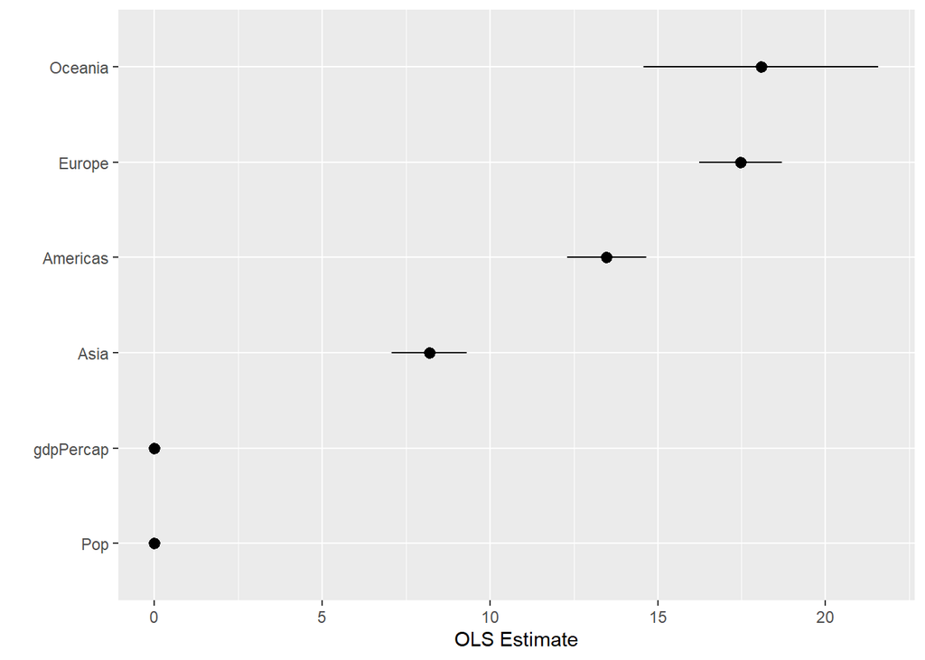

```r
p <- ggplot(out_conf, mapping = aes(x = reorder(nicelabs, estimate), y = estimate, ymin = conf.low, ymax = conf.high))

p + geom_pointrange() + coord_flip() + labs(x = "", y = "OLS Estimate")
```

### 6.5.2 augment()를 사용해 관측 수준 통계보기

값을 반환하는 열은 장착할 모형의 클래스에 따라 약간 다르다.

```r
out_aug <- augment(out)
head(out_aug) %>% round_df()
```

```
## # A tibble: 6 × 10
##   lifeExp gdpPercap      pop conti…¹ .fitted .resid  .hat .sigma .cooksd .std.…²
##     <dbl>     <dbl>    <dbl> <fct>     <dbl>  <dbl> <dbl>  <dbl>   <dbl>   <dbl>
## 1    28.8      779.  8425333 Asia       56.4  -27.6     0   8.34    0.01   -3.31
## 2    30.3      821.  9240934 Asia       56.4  -26.1     0   8.34    0      -3.13
## 3    32        853. 10267083 Asia       56.5  -24.5     0   8.35    0      -2.93
## 4    34.0      836. 11537966 Asia       56.5  -22.4     0   8.35    0      -2.69
## 5    36.1      740. 13079460 Asia       56.4  -20.3     0   8.35    0      -2.44
## 6    38.4      786. 14880372 Asia       56.5  -18.0     0   8.36    0      -2.16
## # … with abbreviated variable names ¹continent, ².std.resid
```

```r
out_aug <- augment(out, data = gapminder)
head(out_aug) %>% round_df()
```

```
## # A tibble: 6 × 12
##   country     continent  year lifeExp    pop gdpPe…¹ .fitted .resid  .hat .sigma
##   <fct>       <fct>     <dbl>   <dbl>  <dbl>   <dbl>   <dbl>  <dbl> <dbl>  <dbl>
## 1 Afghanistan Asia       1952    28.8 8.43e6    779.    56.4  -27.6     0   8.34
## 2 Afghanistan Asia       1957    30.3 9.24e6    821.    56.4  -26.1     0   8.34
## 3 Afghanistan Asia       1962    32   1.03e7    853.    56.5  -24.5     0   8.35
## 4 Afghanistan Asia       1967    34.0 1.15e7    836.    56.5  -22.4     0   8.35
## 5 Afghanistan Asia       1972    36.1 1.31e7    740.    56.4  -20.3     0   8.35
## 6 Afghanistan Asia       1977    38.4 1.49e7    786.    56.5  -18.0     0   8.36
## # … with 2 more variables: .cooksd <dbl>, .std.resid <dbl>, and abbreviated
## #   variable name ¹gdpPercap
```

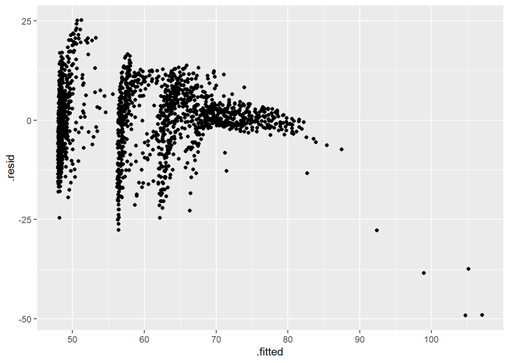

```r
p <- ggplot(data = out_aug, mapping = aes(x = .fitted, y = .resid))
p + geom_point()
```

### 6.5.3 glance()를 사용해 모형 수준 통계 보기

```r
glance(out) %>% round_df()
```

```
## # A tibble: 1 × 12
##   r.squared adj.r.squ…¹ sigma stati…² p.value    df logLik    AIC    BIC devia…³
##       <dbl>       <dbl> <dbl>   <dbl>   <dbl> <dbl>  <dbl>  <dbl>  <dbl>   <dbl>
## 1      0.58        0.58  8.37    394.       0     6 -6034. 12084. 12127. 118754.
## # … with 2 more variables: df.residual <dbl>, nobs <dbl>, and abbreviated
## #   variable names ¹adj.r.squared, ²statistic, ³deviance
```

생존 데이터에 대한 콕스 비례위험모형(Cox Proportional hazards model)을 생성, 신뢰구간 함께 plot

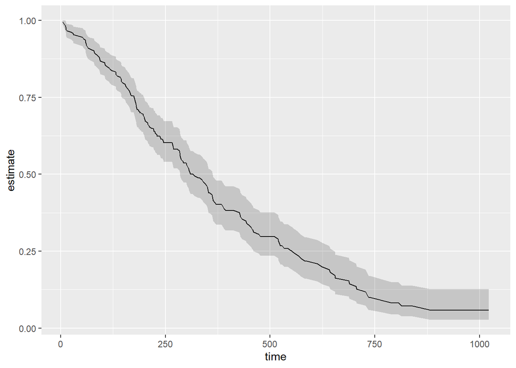

```r
library(survival)

out_cph <- coxph(Surv(time, status) ~ age + sex, data = lung)
out_surv <- survfit(out_cph)
out_tidy <- tidy(out_surv)

p <- ggplot(data = out_tidy, mapping = aes(time, estimate))
p + geom_line() +geom_ribbon(mapping = aes(ymin = conf.low,
                                           ymax = conf.high),
                             alpha = 0.2)
```

## 6.6 그룹화 분석 및 리스트 열

```r
eu77 <- gapminder %>% filter(continent == "Europe", year == 1977)

fit <- lm(lifeExp ~ log(gdpPercap), data = eu77)
summary(fit)
```

```
##
## Call:
## lm(formula = lifeExp ~ log(gdpPercap), data = eu77)
##
## Residuals:
##     Min      1Q  Median      3Q     Max
## -7.4956 -1.0306  0.0935  1.1755  3.7125
##
## Coefficients:
##                Estimate Std. Error t value Pr(>|t|)
## (Intercept)      29.489      7.161   4.118 0.000306 ***
## log(gdpPercap)    4.488      0.756   5.936 2.17e-06 ***
## ---
## Signif. codes:  0 '***' 0.001 '**' 0.01 '*' 0.05 '.' 0.1 ' ' 1
##
## Residual standard error: 2.114 on 28 degrees of freedom
## Multiple R-squared:  0.5572, Adjusted R-squared:  0.5414
## F-statistic: 35.24 on 1 and 28 DF,  p-value: 2.173e-06
```

```r
out_le <- gapminder %>%
  group_by(continent, year) %>%
  nest()
```

```r
out_le
```

```
## # A tibble: 60 × 3
## # Groups:   continent, year [60]
##    continent  year data
##    <fct>     <int> <list>
##  1 Asia       1952 <tibble [33 × 4]>
##  2 Asia       1957 <tibble [33 × 4]>
##  3 Asia       1962 <tibble [33 × 4]>
##  4 Asia       1967 <tibble [33 × 4]>
##  5 Asia       1972 <tibble [33 × 4]>
##  6 Asia       1977 <tibble [33 × 4]>
##  7 Asia       1982 <tibble [33 × 4]>
##  8 Asia       1987 <tibble [33 × 4]>
##  9 Asia       1992 <tibble [33 × 4]>
## 10 Asia       1997 <tibble [33 × 4]>
## # … with 50 more rows
```

```r
out_le %>% filter(continent == "Europe" & year == 1997) %>% unnest()
```

```
## # A tibble: 30 × 6
## # Groups:   continent, year [1]
##    continent  year country                lifeExp      pop gdpPercap
##    <fct>     <int> <fct>                    <dbl>    <int>     <dbl>
##  1 Europe     1997 Albania                   73.0  3428038     3193.
##  2 Europe     1997 Austria                   77.5  8069876    29096.
##  3 Europe     1997 Belgium                   77.5 10199787    27561.
##  4 Europe     1997 Bosnia and Herzegovina    73.2  3607000     4766.
##  5 Europe     1997 Bulgaria                  70.3  8066057     5970.
##  6 Europe     1997 Croatia                   73.7  4444595     9876.
##  7 Europe     1997 Czech Republic            74.0 10300707    16049.
##  8 Europe     1997 Denmark                   76.1  5283663    29804.
##  9 Europe     1997 Finland                   77.1  5134406    23724.
## 10 Europe     1997 France                    78.6 58623428    25890.
## # … with 20 more rows
```

```r
fit_ols <- function(df){
  lm(lifeExp ~ log(gdpPercap), data = df)
}

out_le <- gapminder %>%
  group_by(continent, year) %>%
  nest() %>%
  mutate(model = map(data, fit_ols))

out_le
```

```
## # A tibble: 60 × 4
## # Groups:   continent, year [60]
##    continent  year data              model
##    <fct>     <int> <list>            <list>
##  1 Asia       1952 <tibble [33 × 4]> <lm>
##  2 Asia       1957 <tibble [33 × 4]> <lm>
##  3 Asia       1962 <tibble [33 × 4]> <lm>
##  4 Asia       1967 <tibble [33 × 4]> <lm>
##  5 Asia       1972 <tibble [33 × 4]> <lm>
##  6 Asia       1977 <tibble [33 × 4]> <lm>
##  7 Asia       1982 <tibble [33 × 4]> <lm>
##  8 Asia       1987 <tibble [33 × 4]> <lm>
##  9 Asia       1992 <tibble [33 × 4]> <lm>
## 10 Asia       1997 <tibble [33 × 4]> <lm>
## # … with 50 more rows
```

```r
fit_ols <- function(df){
  lm(lifeExp ~ log(gdpPercap), data = df)
}

out_tidy <- gapminder %>%
  group_by(continent, year) %>%
  nest() %>%
  mutate(model = map(data, fit_ols),
         tidied = map(model, tidy)) %>%
  unnest(tidied, .drop = TRUE) %>%
  filter(term %nin% "(Intercept)" & continent %nin% "Oceania")
out_tidy
```

```
## # A tibble: 48 × 9
## # Groups:   continent, year [48]
##    continent  year data              model term  estim…¹ std.e…² stati…³ p.value
##    <fct>     <int> <list>            <lis> <chr>   <dbl>   <dbl>   <dbl>   <dbl>
##  1 Asia       1952 <tibble [33 × 4]> <lm>  log(…    4.16   1.25     3.33 2.28e-3
##  2 Asia       1957 <tibble [33 × 4]> <lm>  log(…    4.17   1.28     3.26 2.71e-3
##  3 Asia       1962 <tibble [33 × 4]> <lm>  log(…    4.59   1.24     3.72 7.94e-4
##  4 Asia       1967 <tibble [33 × 4]> <lm>  log(…    4.50   1.15     3.90 4.77e-4
##  5 Asia       1972 <tibble [33 × 4]> <lm>  log(…    4.44   1.01     4.41 1.16e-4
##  6 Asia       1977 <tibble [33 × 4]> <lm>  log(…    4.87   1.03     4.75 4.42e-5
##  7 Asia       1982 <tibble [33 × 4]> <lm>  log(…    4.78   0.852    5.61 3.77e-6
##  8 Asia       1987 <tibble [33 × 4]> <lm>  log(…    5.17   0.727    7.12 5.31e-8
##  9 Asia       1992 <tibble [33 × 4]> <lm>  log(…    5.09   0.649    7.84 7.60e-9
## 10 Asia       1997 <tibble [33 × 4]> <lm>  log(…    5.11   0.628    8.15 3.35e-9
## # … with 38 more rows, and abbreviated variable names ¹estimate, ²std.error,
## #   ³statistic
```

이제 대륙 내 1인당 GDP의 로그값과 각 연도별 평균 기대수명 간의 상관관계를 추정해 깔끔한 회귀분석 결과를 얻었다. 이들 그룹의 이점을 이용하는 방식으로 이러한 추정을 도표화할 수 있다.

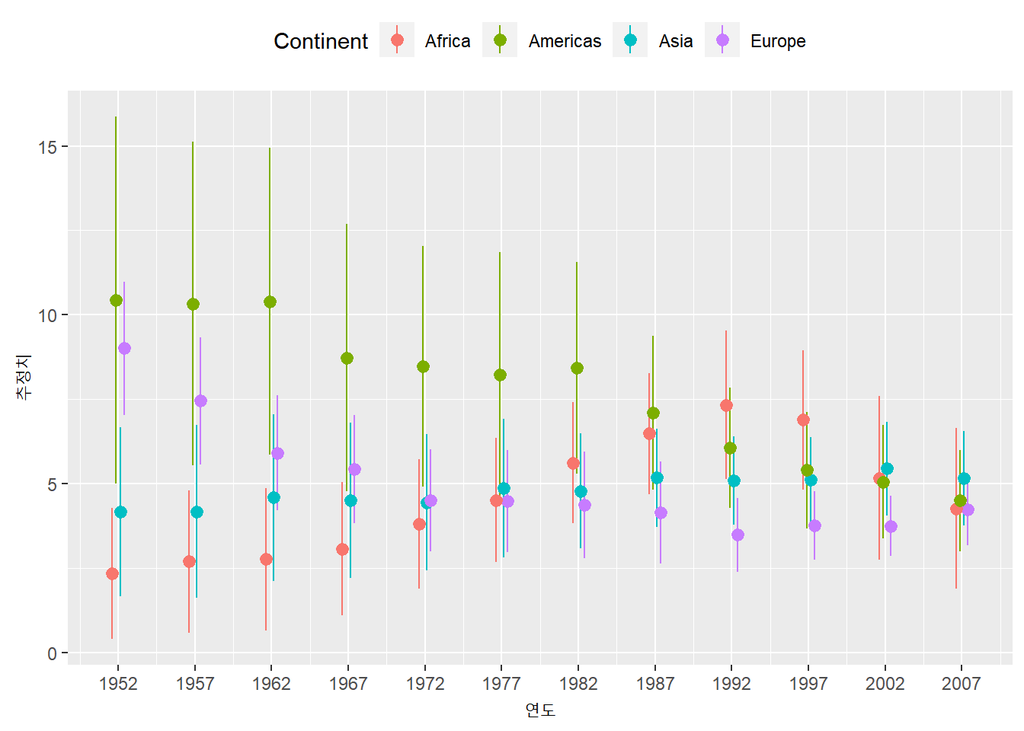

```r
p <- ggplot(data = out_tidy,
            mapping = aes(x = year, y = estimate,
                          ymin = estimate - 2*std.error,
                          ymax = estimate + 2*std.error,
                          group = continent,
                          color = continent))

p + geom_pointrange(position = position_dodge(width = 1)) +
    scale_x_continuous(breaks = unique(gapminder$year)) +
    theme(legend.position = "top") +
    labs(x = "연도", y = "추정치", color = "Continent")
```

## 6.7 플롯 한계 효과

```r
library(margins)

gss_sm$polviews_m <- relevel(gss_sm$polviews, ref = "Moderate")

out_bo <- glm(obama ~ polviews_m + sex*race, family = "binomial", data = gss_sm)

summary(out_bo)
```

```
##
## Call:
## glm(formula = obama ~ polviews_m + sex * race, family = "binomial",
##     data = gss_sm)
##
## Deviance Residuals:
##     Min       1Q   Median       3Q      Max
## -2.9045  -0.5541   0.1772   0.5418   2.2437
##
## Coefficients:
##                                   Estimate Std. Error z value Pr(>|z|)
## (Intercept)                       0.296493   0.134091   2.211  0.02703 *
## polviews_mExtremely Liberal       2.372950   0.525045   4.520 6.20e-06 ***
## polviews_mLiberal                 2.600031   0.356666   7.290 3.10e-13 ***
## polviews_mSlightly Liberal        1.293172   0.248435   5.205 1.94e-07 ***
## polviews_mSlightly Conservative  -1.355277   0.181291  -7.476 7.68e-14 ***
## polviews_mConservative           -2.347463   0.200384 -11.715  < 2e-16 ***
## polviews_mExtremely Conservative -2.727384   0.387210  -7.044 1.87e-12 ***
## sexFemale                         0.254866   0.145370   1.753  0.07956 .
## raceBlack                         3.849526   0.501319   7.679 1.61e-14 ***
## raceOther                        -0.002143   0.435763  -0.005  0.99608
## sexFemale:raceBlack              -0.197506   0.660066  -0.299  0.76477
## sexFemale:raceOther               1.574829   0.587657   2.680  0.00737 **
## ---
## Signif. codes:  0 '***' 0.001 '**' 0.01 '*' 0.05 '.' 0.1 ' ' 1
##
## (Dispersion parameter for binomial family taken to be 1)
##
##     Null deviance: 2247.9  on 1697  degrees of freedom
## Residual deviance: 1345.9  on 1686  degrees of freedom
##   (결측으로 인하여 1169개의 관측치가 삭제되었습니다.)
## AIC: 1369.9
##
## Number of Fisher Scoring iterations: 6
```

```r
bo_m <- margins(out_bo)
summary(bo_m)
```

```
##                            factor     AME     SE        z      p   lower
##            polviews_mConservative -0.4119 0.0283 -14.5394 0.0000 -0.4674
##  polviews_mExtremely Conservative -0.4538 0.0420 -10.7971 0.0000 -0.5361
##       polviews_mExtremely Liberal  0.2681 0.0295   9.0996 0.0000  0.2103
##                 polviews_mLiberal  0.2768 0.0229  12.0736 0.0000  0.2319
##   polviews_mSlightly Conservative -0.2658 0.0330  -8.0596 0.0000 -0.3304
##        polviews_mSlightly Liberal  0.1933 0.0303   6.3896 0.0000  0.1340
##                         raceBlack  0.4032 0.0173  23.3568 0.0000  0.3694
##                         raceOther  0.1247 0.0386   3.2297 0.0012  0.0490
##                         sexFemale  0.0443 0.0177   2.5073 0.0122  0.0097
##    upper
##  -0.3564
##  -0.3714
##   0.3258
##   0.3218
##  -0.2011
##   0.2526
##   0.4371
##   0.2005
##   0.0789
```

```r
bo_gg <- as_tibble(summary(bo_m))
prefixes <- c("polviews", "sex")
bo_gg$factor <- prefix_strip(bo_gg$factor, prefixes)
bo_gg$factor <- prefix_replace(bo_gg$factor, "race", "Race: ")

bo_gg %>% select(factor, AME, lower, upper)
```

```
## # A tibble: 9 × 4
##   factor                       AME    lower   upper
##   <chr>                      <dbl>    <dbl>   <dbl>
## 1 _mconservative           -0.412  -0.467   -0.356
## 2 _mextremely Conservative -0.454  -0.536   -0.371
## 3 _mextremely Liberal       0.268   0.210    0.326
## 4 _mliberal                 0.277   0.232    0.322
## 5 _mslightly Conservative  -0.266  -0.330   -0.201
## 6 _mslightly Liberal        0.193   0.134    0.253
## 7 Race: Black               0.403   0.369    0.437
## 8 Race: Other               0.125   0.0490   0.200
## 9 Female                    0.0443  0.00967  0.0789
```

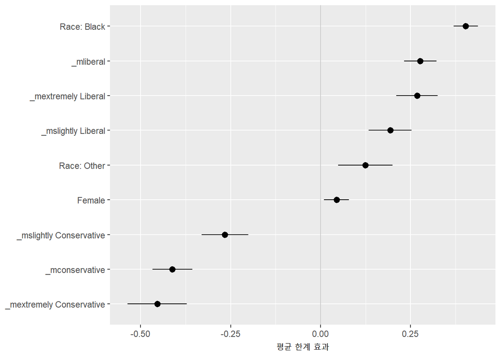

```r
p <- ggplot(data = bo_gg, aes(x = reorder(factor, AME),
                              y = AME,
                              ymin = lower,
                              ymax = upper))

p + geom_hline(yintercept = 0, color = "gray80") +
    geom_pointrange() + coord_flip() +
    labs(x = NULL, y = "평균 한계 효과")
```

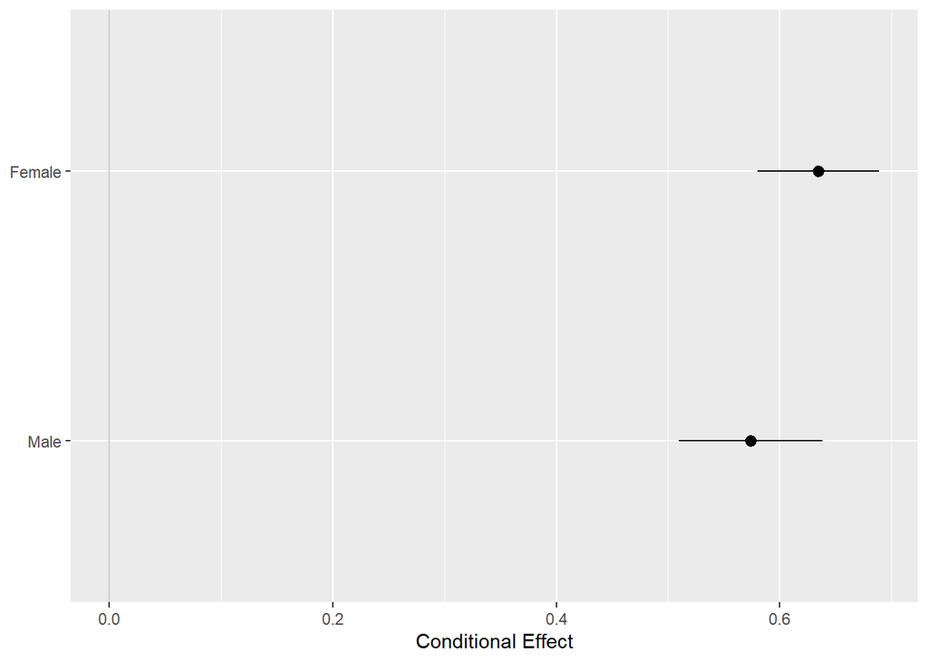

```r
pv_cp <- cplot(out_bo, x = "sex", draw = FALSE)
p <- ggplot(data = pv_cp, aes(x = reorder(xvals, yvals),
                              y = yvals,
                              ymin = lower,
                              ymax = upper))

p + geom_hline(yintercept = 0, color = "gray80") +
    geom_pointrange() + coord_flip() +
    labs(x = NULL, y = "Conditional Effect")
```

## 6.8 복잡한 설문 조사 도표

```r
library(survey)
library(srvyr)
```

- 데이터 전처리
- 디자인 정보를 사용해 1976년부터 2016년까지 선택된 설문 조사 연도에 대한 인종별 학력 분포의 가중치 산정 계산
1. gss_wt: gss_lon 데이터셋을 가져와 survey 도구 사용 이전과 같이 설문조사의 디자인에 대한 추가 정보와 함께 데이터가 포함된 새 객체 생성
2. out_grp: 1976년부터 2016년까지 일련의 인종별 교육 분포
3. out_mrg: 인종별 학위에 대한 상호작용 추가
4. out_mrg2: seperate 함수 이용 인종별-학위별 레이블 기입

```r
options(survey.lonely.psu = "adjust")
options(na.action = "na.pass")

gss_wt <- subset(gss_lon, year > 1974) %>%
            mutate(stratvar = interaction(year, vstrat)) %>%
            as_survey_design(ids = vpsu,
                             strata = stratvar,
                             weights = wtssall,
                             nest = TRUE)

out_grp <- gss_wt %>%
            filter(year %in% seq(1976, 2016, by = 4)) %>%
            group_by(year, race, degree) %>%
            summarize(prop = survey_mean(na.rm = TRUE))

out_mrg <- gss_wt %>%
            filter(year %in% seq(1976, 2016, by = 4)) %>%
            mutate(racedeg = interaction(race, degree)) %>%
            group_by(year,  racedeg) %>%
            summarize(prop = survey_mean(na.rm = TRUE))

out_mrg2 <- gss_wt %>%
            filter(year %in% seq(1976, 2016, by = 4)) %>%
            mutate(racedeg = interaction(race, degree)) %>%
            group_by(year, racedeg) %>%
            summarize(prop = survey_mean(na.rm = TRUE)) %>%
            separate(racedeg, sep = "\\.", into = c("race", "degree"))
```

- 점 추정치 주변의 표준오차*2의 크기로 정의된 오차 막대가 추가된 다이너마이트 도표 플랏

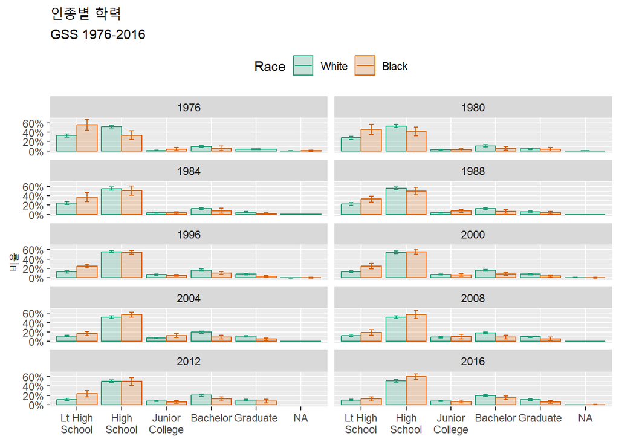

```r
p <- ggplot(data = subset(out_grp, race %nin% "Other"),
            mapping = aes(x = degree, y = prop,
                          ymin = prop - 2*prop_se,
                          ymax = prop + 2*prop_se,
                          fill = race,
                          color = race,
                          group = race))

dodge <- position_dodge(width = 0.9)

p + geom_col(position = dodge, alpha = 0.2) +
    geom_errorbar(position = dodge, width = 0.2) +
    scale_x_discrete(labels = scales::wrap_format(10)) +
    scale_y_continuous(labels = scales::percent) +
    scale_color_brewer(type = "qual", palette = "Dark2") +
    scale_fill_brewer(type = "qual", palette = "Dark2") +
    labs(title = "인종별 학력",
         subtitle = "GSS 1976-2016",
         fill = "Race",
         color = "Race",
         x = NULL, y = "비율") +
    facet_wrap(~ year, ncol = 2) +
    theme(legend.position = "top")
```

막대그래프를 이용한 facet_wrap은 종종 좋지 못한 아이디어이며, 다중 그림이 많을수록 더 나빠짐

- 학위 카테고리별 패시팅 및 각 패널의 x축에 연도를 추가한 geom_line() 생성

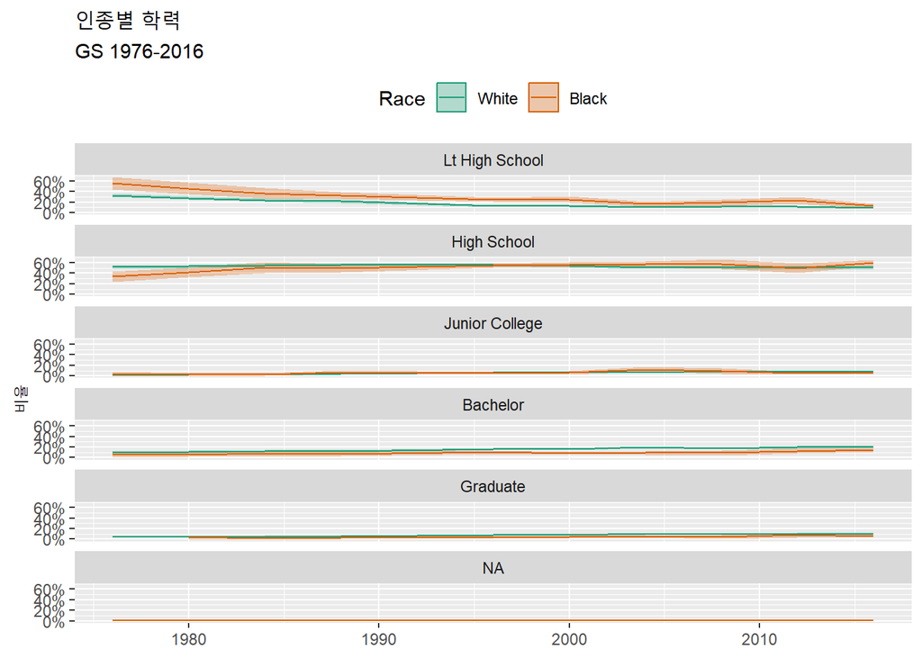

```r
p <- ggplot(data = subset(out_grp, race %nin% "Other"),
            mapping = aes(x = year, y = prop,
                          ymin = prop - 2*prop_se,
                          ymax = prop + 2*prop_se,
                          fill = race,
                          color = race,
                          group = race))

p + geom_ribbon(alpha = 0.3, aes(color = NULL)) +
    geom_line() +
    facet_wrap(~ degree, ncol = 1) +
    scale_y_continuous(labels = scales::percent) +
    scale_color_brewer(type = "qual", palette = "Dark2") +
    scale_fill_brewer(type = "qual", palette = "Dark2") +
    labs(title = "인종별 학력",
         subtitle = "GS 1976-2016",
         fill = "Race",
         color = "Race",
         x = NULL,
         y = "비율") +
    theme(legend.position = "top")
```